# Exploratory Data Analysis in R

James Sacco

3/28/2018

### STATISTICS FOR GENOMIC DATA SCIENCE: MODULE 1

## EXPLORATORY DATA ANALYSIS IN R

reference: http://jtleek.com/genstats/inst/doc/01_10_exploratory-analysis.html

## PART 1

use the below code if you need to download a CRAN package from BioConductor

source(“http://bioconductor.org/biocLite.R”) biocLite(“pkgname”)

```r
rm(list=ls())
```

load libraries

```r
library(gplots)
library(devtools)
library(Biobase)
library("RSkittleBrewer", lib.loc="/Library/Frameworks/R.framework/Versions/3.3/Resources/library")
library(org.Hs.eg.db)
library(AnnotationDbi)
library(dplyr)
```

make plots pretty

```r
trop = RSkittleBrewer("tropical")
palette(trop)

par(pch=19)
```

[output not shown]

[output not shown]

use the above code chunk to start each Part (1,2,3)

summarize data

```r
table(pdata$gender)
```

```
##
## F M
## 8 8
```

```r
table(pdata$gender, pdata$race)
```

```
##
##     african_american caucasian
##   F                1         7
##   M                0         8
```

```r
summary(edata)
```

```
##    ERS025098           ERS025092          ERS025085
##  Min.   :      0.0   Min.   :     0.0   Min.   :     0.0
##  1st Qu.:      0.0   1st Qu.:     0.0   1st Qu.:     0.0
##  Median :      0.0   Median :     0.0   Median :     0.0
##  Mean   :    455.6   Mean   :   361.1   Mean   :   399.3
##  3rd Qu.:      0.0   3rd Qu.:     0.0   3rd Qu.:     0.0
##  Max.   :1584528.0   Max.   :499802.0   Max.   :808641.0
##    ERS025088           ERS025089         ERS025082
##  Min.   :      0.0   Min.   :      0   Min.   :      0
##  1st Qu.:      0.0   1st Qu.:      0   1st Qu.:      0
##  Median :      0.0   Median :      0   Median :      0
##  Mean   :    445.5   Mean   :    445   Mean   :    509
##  3rd Qu.:      0.0   3rd Qu.:      0   3rd Qu.:      0
##  Max.   :1014579.0   Max.   :1415741   Max.   :2484692
##    ERS025081           ERS025096         ERS025099
##  Min.   :      0.0   Min.   :      0   Min.   :     0.0
##  1st Qu.:      0.0   1st Qu.:      0   1st Qu.:     0.0
##  Median :      0.0   Median :      0   Median :     0.0
##  Mean   :    430.4   Mean   :    558   Mean   :   445.5
##  3rd Qu.:      0.0   3rd Qu.:      0   3rd Qu.:     0.0
##  Max.   :1356643.0   Max.   :3517964   Max.   :572374.0
##    ERS025086          ERS025084          ERS025087
##  Min.   :     0.0   Min.   :     0.0   Min.   :     0
##  1st Qu.:     0.0   1st Qu.:     0.0   1st Qu.:     0
##  Median :     0.0   Median :     0.0   Median :     0
##  Mean   :   370.7   Mean   :   592.1   Mean   :  1097
##  3rd Qu.:     0.0   3rd Qu.:     0.0   3rd Qu.:     0
##  Max.   :458168.0   Max.   :287539.0   Max.   :519683
##    ERS025093           ERS025083          ERS025095
##  Min.   :      0.0   Min.   :     0.0   Min.   :      0.0
##  1st Qu.:      0.0   1st Qu.:     0.0   1st Qu.:      0.0
##  Median :      0.0   Median :     0.0   Median :      0.0
##  Mean   :    997.7   Mean   :   434.7   Mean   :    479.6
##  3rd Qu.:      0.0   3rd Qu.:     0.0   3rd Qu.:      0.0
##  Max.   :1332827.0   Max.   :626824.0   Max.   :1605570.0
##    ERS025097           ERS025094          ERS025090
##  Min.   :      0.0   Min.   :     0.0   Min.   :     0.0
##  1st Qu.:      0.0   1st Qu.:     0.0   1st Qu.:     0.0
##  Median :      0.0   Median :     0.0   Median :     0.0
##  Mean   :    540.1   Mean   :   518.5   Mean   :   465.3
##  3rd Qu.:      0.0   3rd Qu.:     0.0   3rd Qu.:     0.0
##  Max.   :1888083.0   Max.   :776623.0   Max.   :535410.0
##    ERS025091
##  Min.   :      0.0
##  1st Qu.:      0.0
##  Median :      0.0
##  Mean   :    530.1
##  3rd Qu.:      0.0
##  Max.   :1221921.0
```

missing values Use option useNA to include NA’s in table

```r
table(pdata$age, useNA = "ifany")
```

```
##
##   19   29   37   47   58   60   65   68   73   77   86 <NA>
##    1    1    1    1    1    3    1    1    2    3    1    3
```

is.na checks for NA values

```r
table(is.na(pdata$age))
```

```
##
## FALSE  TRUE
##    16     3
```

Check for other common missing names

```r
sum(pdata$age == " ")
```

```
## [1] NA
```

remove NAs in age column

```r
sum(pdata$age == " ", na.rm=TRUE)
```

```
## [1] 0
```

check genomic data for NAs

```r
sum(is.na(edata))
```

```
## [1] 0
```

make the distribution of NAs by gene

```r
gene_na = rowSums(is.na(edata))
table(gene_na)
```

```
## gene_na
##     0
## 52580
```

```r
sample_na = rowSums(is.na(edata))
table(sample_na)
```

```
## sample_na
##     0
## 52580
```

Check that dimensions match up

The number of rows of the feature data should match the number of rows of the genomic data (both are the number of genes). The number of rows of the phenotype data should match the number of columns of the genomic data (both are the number of samples).

dimenensions

```r
dim(fdata) #features data
```

```
## [1] 52580     1
```

```r
dim(pdata) #phenotype data
```

```
## [1] 19  6
```

```r
dim(edata) #expression data
```

```
## [1] 52580    19
```

## PART 2

Look at overall distributions

```r
rm(list=ls())
library(gplots)
library(devtools)
library(Biobase)
library("RSkittleBrewer", lib.loc="/Library/Frameworks/R.framework/Versions/3.3/Resources/library")
library(org.Hs.eg.db)
library(AnnotationDbi)
library(dplyr)
```

```r
con = url("http://bowtie-bio.sourceforge.net/recount/ExpressionSets/bodymap_eset.RData")
load(file=con)
close(con)
bm = bodymap.eset
pdata = pData(bm)
edata = exprs(bm)
fdata = fData(bm)
ls()
```

```
## [1] "bm"           "bodymap.eset" "con"          "edata"
## [5] "fdata"        "pdata"
```

boxplot

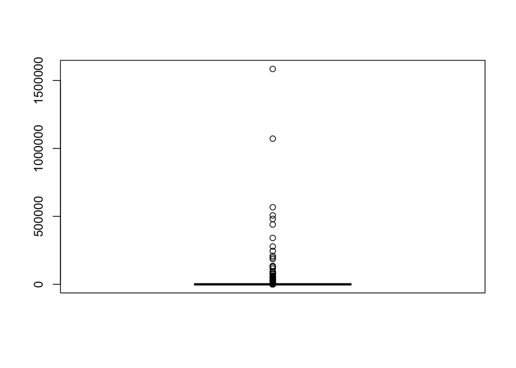

```r
boxplot(edata[,1])
```

The above is a useless plot; most of values are near zero, and there are many outliers

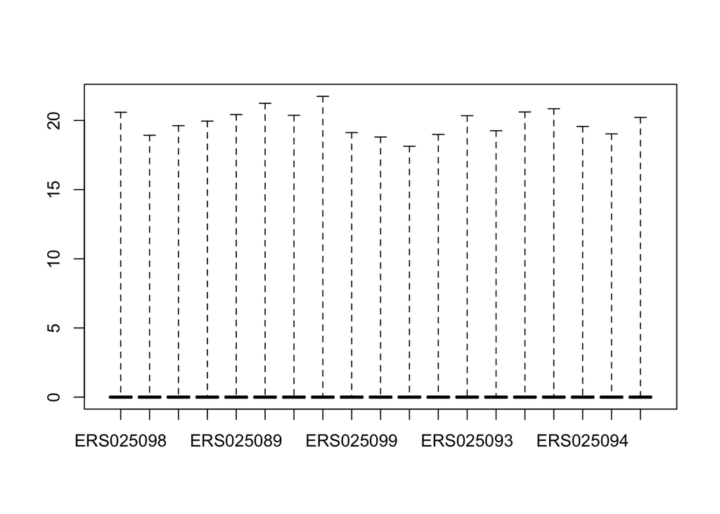

```r
boxplot(log2(edata+1), col=2, range=0)
```

Histograms

look at this, sample by sample, with histograms

show plots side by side on the screan: 1 row and 2 columns of plots

```r
par(mfrow=c(1,2))
```

almost all values are equal to 0

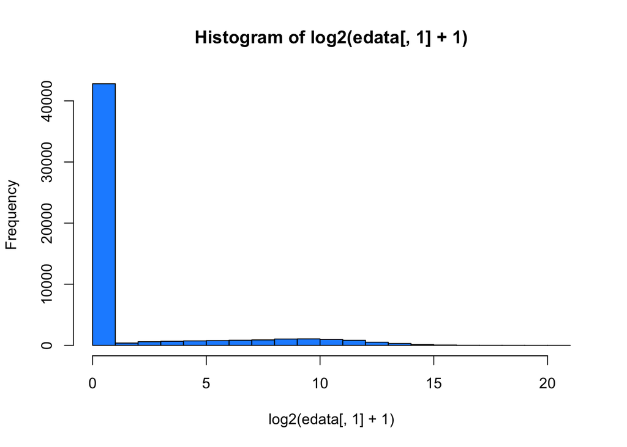

```r
hist(log2(edata[,1]+1),col=2)
```

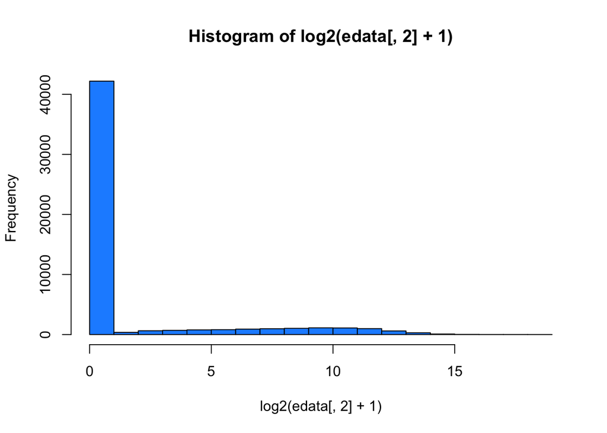

```r
hist(log2(edata[,2]+1),col=2)
```

change display for plots 1 row and 1 column of plots

```r
par(mfrow=c(1,1))
```

density plot of sample 1

log transform and density of 1st sample

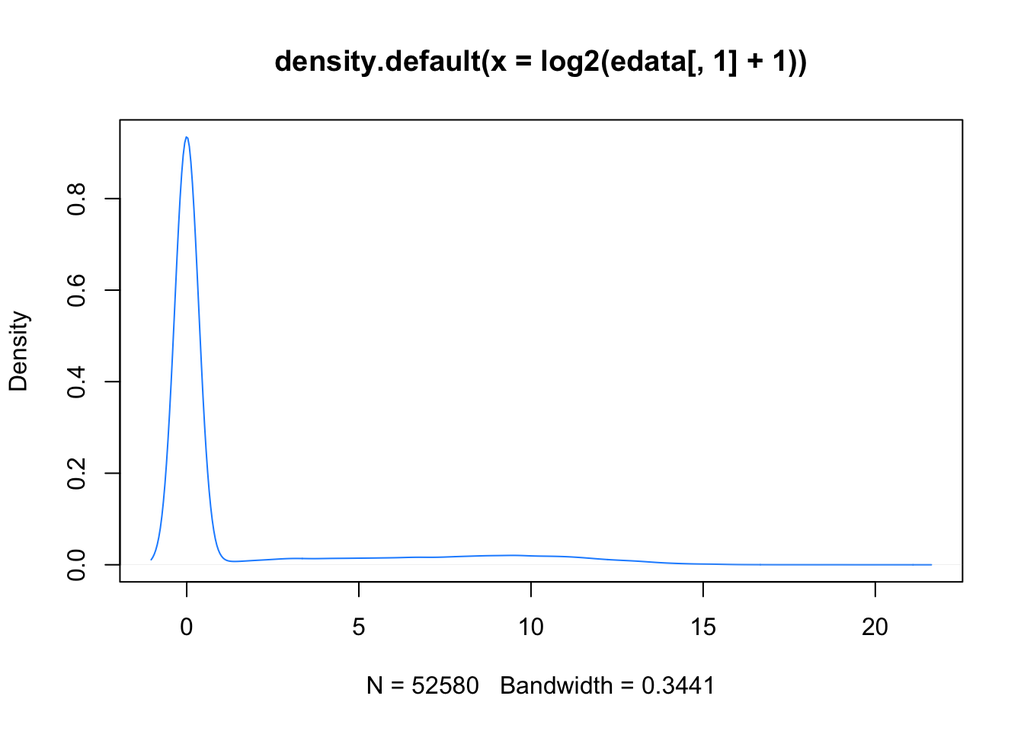

```r
plot(density(log2(edata[,1]+1)), col=2)
```

add density plot of sample 2

layer other values on top with the lines command

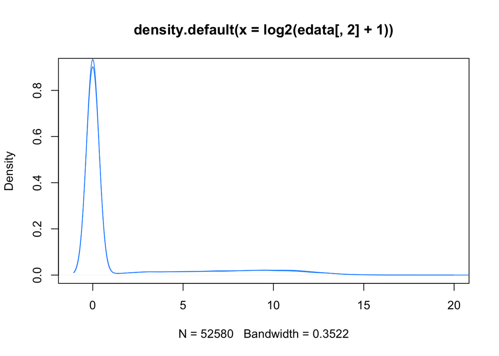

```r
plot(density(log2(edata[,2]+1)), col=2)

lines(density(log2(edata[,1]+1)), col=2)
```

A very common task is to compare distributions of measurements (say, before normalization). You can do this with a qq-plot

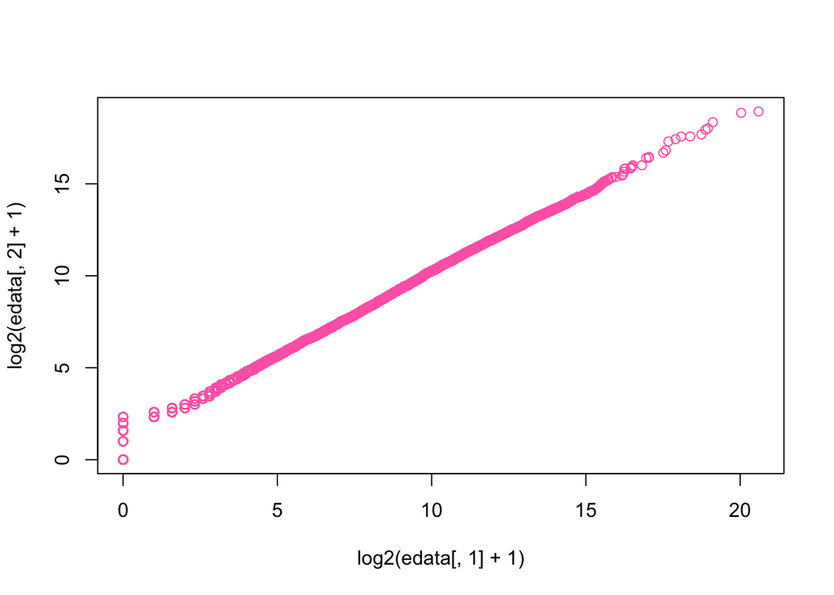

```r
qqplot(log2(edata[,1]+1),log2(edata[,2]+1), col=3)
```

add 45 degree line to the qqplot with abline function

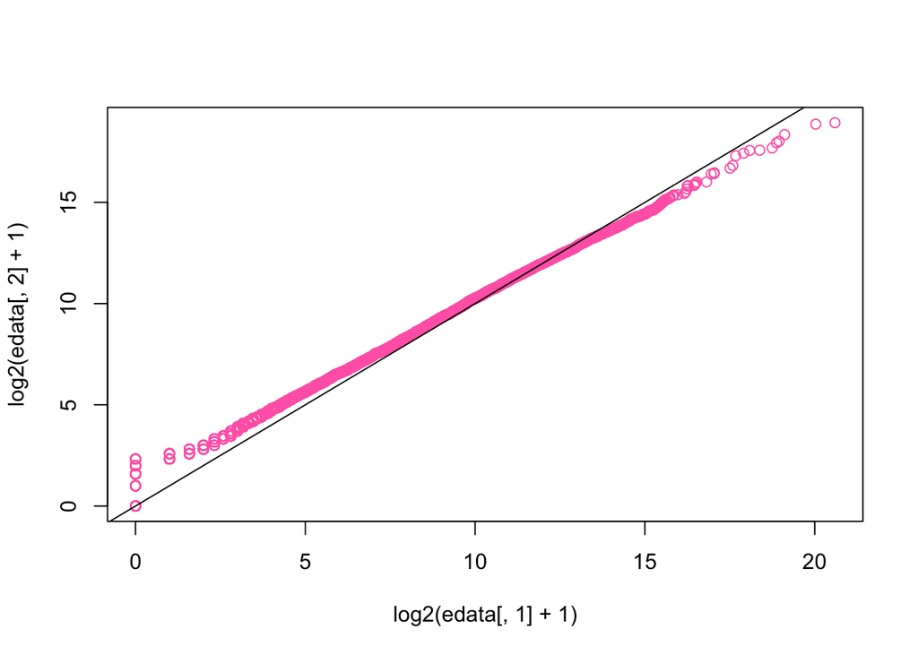

```r
qqplot(log2(edata[,1]+1),log2(edata[,2]+1), col=3)
abline(c(0,1))
```

make an M.A. Plot aka Bland-Altman Plot

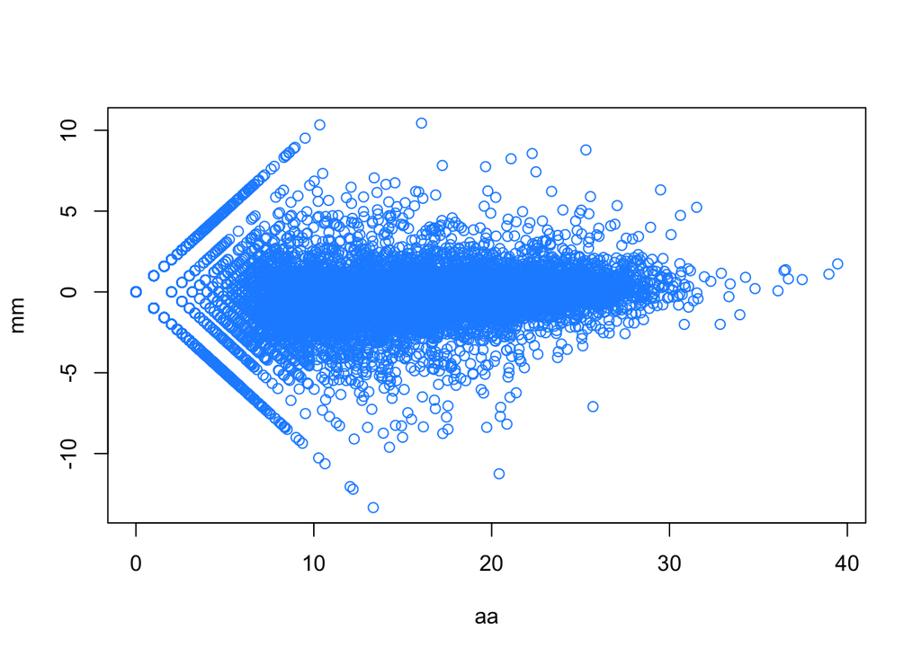

```r
mm = log2(edata[,1]+1) - log2(edata[,2]+1)
aa = log2(edata[,1]+1) + log2(edata[,2]+1)

plot(aa, mm, col=2)
```

for count based data, you need to remove low count features

(convert to dataframe to filter, and then convert to matrix to plot)

```r
edata = as.data.frame(edata) #convert to dataframe to filter


filt_edata = filter(edata, rowMeans(edata) > 1)
dim(filt_edata)
```

```
## [1] 12276    19
```

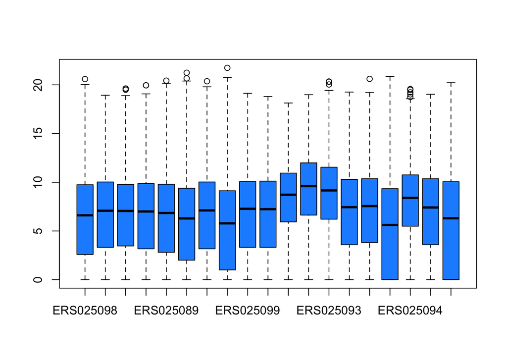

```r
boxplot(as.matrix(log2(filt_edata +1)), col = 2) #convert to matrix to plot
```

## PART 3

CHECK FOR CONSISTENCY (or obvious data mixups). Compare data to metadata or other annotations

Here we are going to do a check to make sure that the men and women are correctly labeled by looking at expression on the Y chromosome. In general you might do several of this type of check to confirm the data are correctly labeled.

Get the chromosomes for each gene using the feature data.

```r
aeid = as.character(fdata[,1])
chr = AnnotationDbi::select(org.Hs.eg.db,keys=aeid,keytype="ENSEMBL",columns="CHR")
head(chr)
```

```
##           ENSEMBL CHR
## 1 ENSG00000000003   X
## 2 ENSG00000000005   X
## 3 ENSG00000000419  20
## 4 ENSG00000000457   1
## 5 ENSG00000000460   1
## 6 ENSG00000000938   1
```

Filter to the data on chromsome Y and sum up all the counts. A tricky issue is that some genes are annotated to multiple chromsomes.

Here we take the first chromsome each is annotated to.

```r
dim(chr)
```

```
## [1] 52631     2
```

```r
dim(edata)
```

```
## [1] 52580    19
```

Take non-duplicated chromsomes

```r
chr = chr[!duplicated(chr[,1]),]
```

confirm that the annotation is still in the right order

```r
all(chr[,1] == rownames(edata))
```

```
## [1] TRUE
```

Select the chromosome Y samples

```r
edatay = dplyr::filter(edata,chr$CHR=="Y")
```

Note: if the above command does not work, you may need to use this work-around to eliminate the error, but you will get non-zero female values: edatay = dplyr::filter(as.data.frame(edata, as.character(chr$CHR==“Y”)))

Males have Y chromosome expression as expected

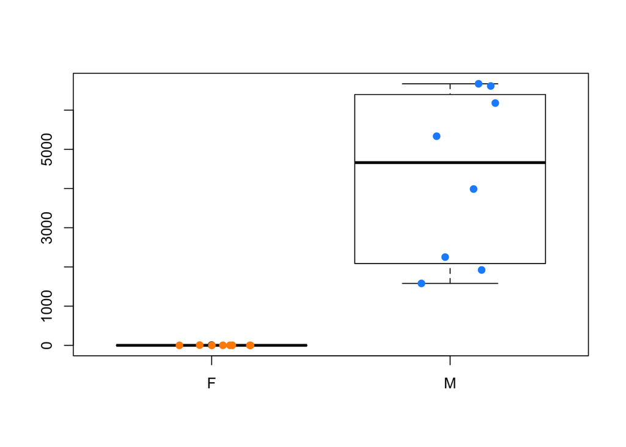

```r
boxplot(colSums(edatay) ~ pdata$gender)
points(colSums(edatay) ~ jitter(as.numeric(pdata$gender)),
       col=as.numeric(pdata$gender),
       p=19)
```

heatmaps

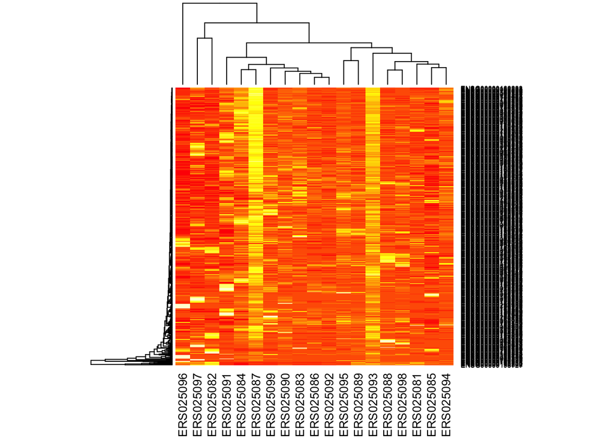

```r
ematrix = as.matrix(edata)[rowMeans(edata) > 10000,]
heatmap(ematrix)
```

change the coloring. make a color palette

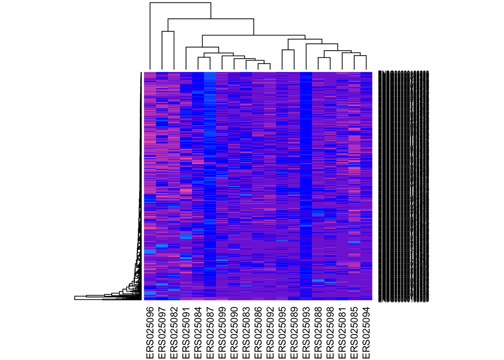

```r
colramp = colorRampPalette(c(3,"blue",2))(9)
heatmap(ematrix,col=colramp)
```

remove automatic clustering

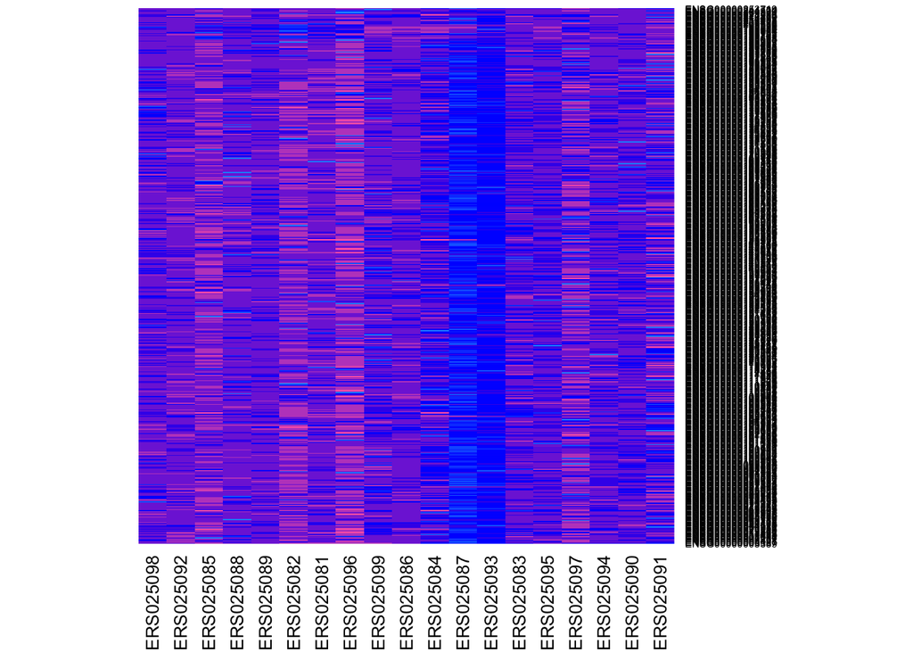

```r
heatmap(ematrix, col=colramp, Rowv = NA, Colv = NA)
```

Add color scale with heatmap.2 package. Make dendrogram disappear, scale the data by rows, and remove a tracing plot

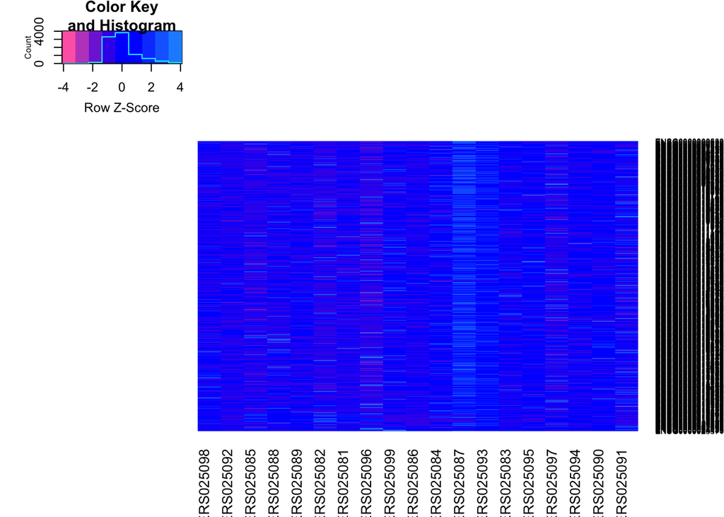

[output not shown]

[output not shown]

[output not shown]

[output cut: 53 more lines]

[output not shown]

```r
heatmap.2(ematrix,col=colramp,Rowv = NA, Colv = NA, dendrogram = "none", scale = "row", trace = "none")
```